# 📊 Peace & Wellbeing Index (PWI) Dashboard — Causal Forecast

This dashboard simulates how violence, governance, and wellbeing evolved across history and may evolve into the future — **not through projection, but based on causal factors**.

We model two future paths:

- **Projected Trend**: Continuation of today’s military, ecological, and governance trends.
- **Kōra Vision**: Emergence of restorative systems, ecological recovery, and participatory governance.

All KPIs are calculated from fundamental inputs — not assumptions.

```python
import pandas as pd
import matplotlib.pyplot as plt
import seaborn as sns
sns.set(style="whitegrid")

df = pd.read_csv("../data/data_processed.csv")
df.head()
```

|  | Era | Military Intensity | Climate Stability | Governance Score | Inequality Index | Social Trust | Mental Health Index | Violence Index (VI) | Wellbeing Score (WS) | Governance Score (1–5) |
| --- | --- | --- | --- | --- | --- | --- | --- | --- | --- | --- |
| 0 | Ancient | 0.6 | 80 | 2.0 | 40 | 50 | 60 | 60.0 | 62.5 | 2.0 |
| 1 | Medieval | 0.9 | 85 | 1.5 | 60 | 30 | 45 | 90.0 | 50.0 | 1.5 |
| 2 | Early Modern | 0.8 | 75 | 2.5 | 70 | 35 | 40 | 80.0 | 45.0 | 2.5 |
| 3 | Modern | 0.4 | 60 | 4.0 | 80 | 45 | 55 | 40.0 | 45.0 | 4.0 |
| 4 | Forecast: Projected | 0.5 | 45 | 3.5 | 85 | 40 | 50 | 50.0 | 37.5 | 3.5 |

## 🔴 Violence Index (VI)

**Formula:**  
`VI = Military Intensity × 100`

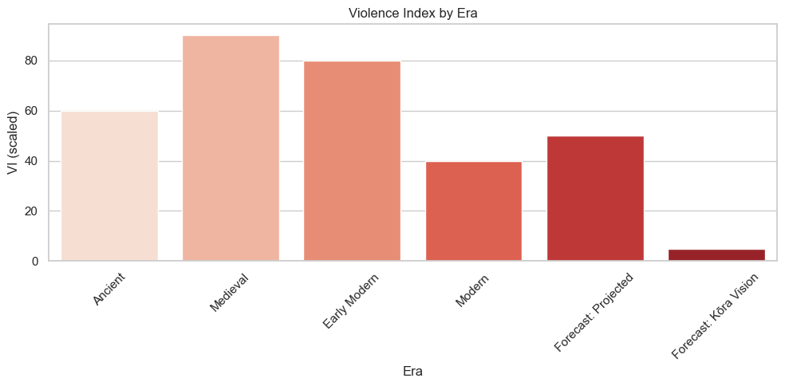

```python
plt.figure(figsize=(10, 5))
sns.barplot(x="Era", y="Violence Index (VI)", data=df, palette="Reds")
plt.title("Violence Index by Era")
plt.ylabel("VI (scaled)")
plt.xlabel("Era")
plt.xticks(rotation=45)
plt.tight_layout()
plt.show()
```

## 🟢 Wellbeing Score (WS)

**Formula:**

```
WS = (Climate Stability × 0.25) +
     ((100 - Inequality Index) × 0.25) +
     (Social Trust × 0.25) +
     (Mental Health Index × 0.25)
```

Represents peace, sustainability, mental/emotional health, and social harmony.  
Higher WS means a better quality of life for the average person.

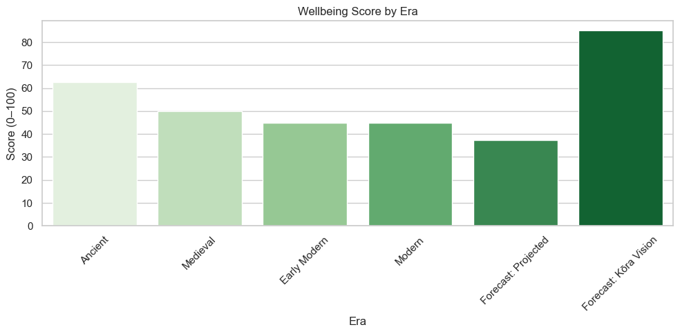

```python
plt.figure(figsize=(10, 5))
sns.barplot(x="Era", y="Wellbeing Score (WS)", data=df, palette="Greens")
plt.title("Wellbeing Score by Era")
plt.ylabel("Score (0–100)")
plt.xlabel("Era")
plt.xticks(rotation=45)
plt.tight_layout()
plt.show()
```

## 🟦 Governance Alignment Score (1–5)

Reflects how aligned each era’s system is with peace-promoting governance.  
**1 = Autocracy / Authoritarian Rule**  
**5 = Democratic / Restorative Governance**

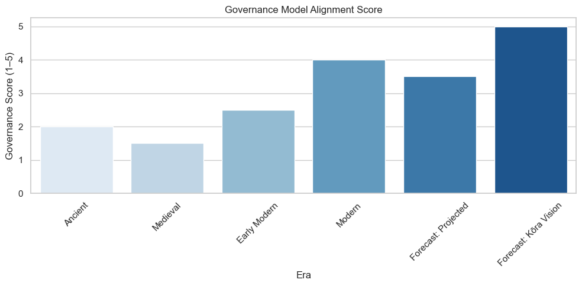

```python
plt.figure(figsize=(10, 5))
sns.barplot(x="Era", y="Governance Score (1–5)", data=df, palette="Blues")
plt.title("Governance Model Alignment Score")
plt.ylabel("Governance Score (1–5)")
plt.xlabel("Era")
plt.xticks(rotation=45)
plt.tight_layout()
plt.show()
```

## 🧠 Interpretation

**This dashboard demonstrates that peace and wellbeing do not require utopia — they require causality, wisdom, and shared responsibility.**

Explore the full repository: [Kōra Restorative Toolkit](https://github.com/Kora-Restore/kora-restorative-toolkit)